# Egenhofer-topologi

Samt to måter å opprette GeoDataFrames på.

Referanser som gir bakgunn for å forstå eksemplene nedenfor:

### Utvalgte referanser

- [Shapely Polygons](https://shapely.readthedocs.io/en/latest/manual.html#polygons)
- [pandas.DataFrame.from_dict](https://pandas.pydata.org/pandas-docs/stable/reference/api/pandas.DataFrame.from_dict.html#pandas-dataframe-from-dict)
- [pandas.Series.apply](https://pandas.pydata.org/pandas-docs/stable/reference/api/pandas.Series.apply.html?highlight=apply#pandas-series-apply)
- [pandas.Series.any](https://pandas.pydata.org/pandas-docs/stable/reference/api/pandas.Series.any.html?highlight=any#pandas-series-any)
- [Binary predicates -oversikt](https://geopandas.org/docs/reference/geoseries.html#binary-predicates)
- touches
- contains
- intersects
- [overlaps](https://geopandas.org/docs/reference/api/geopandas.GeoSeries.intersects.html#geopandas-geoseries-intersects)
- sjoin
- overlay

### Introduksjon

- [Data Structures](https://geopandas.org/docs/user_guide/data_structures.html)
- [GeoSeries](https://geopandas.org/docs/user_guide/data_structures.html#geoseries)
- [GeoDataFrame](https://geopandas.org/docs/user_guide/data_structures.html#geodataframe)

### Referanser

- [GeoSeries](https://geopandas.org/docs/reference/geoseries.html)
- [GeoDataFrame](https://geopandas.org/docs/reference/geodataframe.html)
- [Input/Output](https://geopandas.org/docs/reference/io.html)
- [Tools - inkludert Spatial Join](https://geopandas.org/docs/reference/tools.html)
- [API Reference](https://geopandas.org/docs/reference.html)

### Shapely

- [Introduction: The Shapely User Manual](https://shapely.readthedocs.io/en/latest/manual.html)
- [Documentation Contents: The Shapely User Manual](https://shapely.readthedocs.io/en/latest/)
- [Spatial Analysis Methods: Set-theoretic Methods](https://shapely.readthedocs.io/en/latest/manual.html#set-theoretic-methods)
- [Spatial Analysis Methods: Constructive Methods](https://shapely.readthedocs.io/en/latest/manual.html#constructive-methods)

### Pandas

- [What kind of data does pandas handle?](https://pandas.pydata.org/pandas-docs/stable/getting_started/intro_tutorials/01_table_oriented.html#what-kind-of-data-does-pandas-handle)
- [How do I select a subset of a DataFrame?](https://pandas.pydata.org/pandas-docs/stable/getting_started/intro_tutorials/03_subset_data.html#how-do-i-select-a-subset-of-a-dataframe)
- [How do I filter specific rows from a DataFrame?](https://pandas.pydata.org/pandas-docs/stable/getting_started/intro_tutorials/03_subset_data.html#how-do-i-filter-specific-rows-from-a-dataframe)
- [How to create plots in pandas?](https://pandas.pydata.org/pandas-docs/stable/getting_started/intro_tutorials/04_plotting.html#how-to-create-plots-in-pandas)
- [Merge, join, concatenate and compare](https://pandas.pydata.org/pandas-docs/stable/user_guide/merging.html#merge-join-concatenate-and-compares)
- [API Reference: Series](https://pandas.pydata.org/pandas-docs/stable/reference/series.html#series)
- [API Reference: DataFrame](https://pandas.pydata.org/pandas-docs/stable/reference/frame.html#dataframe)

```
NTNU 01.03.2021 - Sverre Stikbakke
NTNU 26.03.2022 - Oppdatert med Spatial Join og Overlay
```

## Oppretting av GeoDataFrame med .from_dict -funksjon (fra dictionary)

```python
import pandas as pd
import geopandas as gpd
import fiona as fi
from shapely.geometry import Polygon, Point
```

```python
# Python dictionary (en innebygd datastruktur i Python)

data = {'smaragd': {
    'localid': 446124344,
    'objtype': 'Teig',
    'SHAPE_Length': 306.207095792018,
    'SHAPE_Area': 5747.21023925478,
    'geometry': Polygon([
        [591518.2, 6740464.0499],
        [591442.74, 6740401.1999],
        [591399.69, 6740452.8699],
        [591460.55, 6740518.9299],
        [591464.35, 6740525.3999],
        [591471.27, 6740517.5099],
        [591516.35, 6740466.1499],
        [591518.2, 6740464.0499],
        ]),
    }, 'beryll': {
    'localid': 49174530,
    'objtype': 'Teig',
    'SHAPE_Length': 306.207095792018,
    'SHAPE_Area': 5747.21023925478,
    'geometry': Polygon([
        [591535.31, 6740542.8499],
        [591546.79, 6740525.9499],
        [591565.3179, 6740498.2083],
        [591527.4193, 6740467.2872],
        [591516.35, 6740466.1499],
        [591471.27, 6740517.5099],
        [591464.35, 6740525.3999],
        [591494.5, 6740576.6499],
        [591514.4, 6740554.4999],
        [591525.4, 6740550.7899],
        [591535.31, 6740542.8499],
        ]),
    }}
```

```python
teiger = gpd.GeoDataFrame.from_dict(data, orient='index')
teiger.crs = 'EPSG:25832'
```

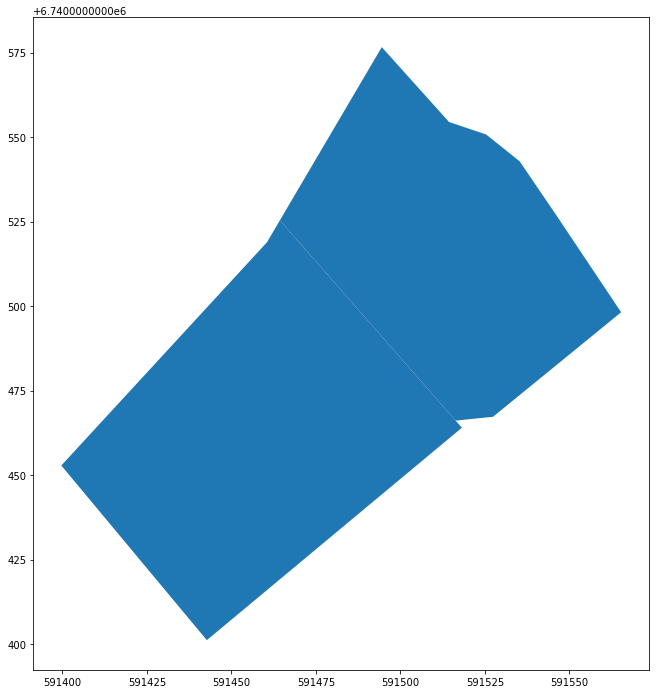

```python
teiger.plot(figsize=(12,12))
```

### Egenhofer-relasjoner testet på enkelt-geometrier

```python
# Hele geometri-kolonnen er en GeoSeries
print(teiger.loc[:, 'geometry'])
print(type(teiger.loc[:, 'geometry']))
```

```
smaragd    POLYGON ((591518.200 6740464.050, 591442.740 6...
beryll     POLYGON ((591535.310 6740542.850, 591546.790 6...
Name: geometry, dtype: geometry
<class 'geopandas.geoseries.GeoSeries'>
```

```python
# Ett element i en GeoSeries er en Shapely geometri-type
print(teiger.loc['smaragd', 'geometry'])
print(type(teiger.loc['smaragd', 'geometry']))
```

```
POLYGON ((591518.2 6740464.0499, 591442.74 6740401.1999, 591399.69 6740452.8699, 591460.55 6740518.9299, 591464.35 6740525.3999, 591471.27 6740517.5099, 591516.35 6740466.1499, 591518.2 6740464.0499))
<class 'shapely.geometry.polygon.Polygon'>
```

```python
# Her henter vi ut geometriene hver for seg og tester relasjonen mellom dem
print('Smaragd-teigen berører Beryll-teigen? ', teiger.loc['smaragd', 'geometry'].touches(teiger.loc['beryll', 'geometry']))
print('Smaragd-teigen ligger inne i Beryll-teigen? ', teiger.loc['smaragd', 'geometry'].contains(teiger.loc['beryll', 'geometry']))
print('Smaragd-teigen krysser (intersects) Beryll-teigen? ', teiger.loc['smaragd', 'geometry'].intersects(teiger.loc['beryll', 'geometry']))
print('Smaragd-teigen overlapper Beryll-teigen? ', teiger.loc['smaragd', 'geometry'].overlaps(teiger.loc['beryll', 'geometry']))
```

```
Smaragd-teigen berører Beryll-teigen?  True
Smaragd-teigen ligger inne i Beryll-teigen?  False
Smaragd-teigen krysser (intersects) Beryll-teigen?  True
Smaragd-teigen overlapper Beryll-teigen?  False
```

```python
teiger.contains(Point([591437,6740440]))
```

```
smaragd     True
beryll     False
dtype: bool
```

### Oppretting av GeoDataframe ved innlesing fra fil

```python
# fila som importeres her har Geopackage-format. Det er eksportert fra QGIS.
bygninger = gpd.read_file('bygninger_buffer.gpkg')
```

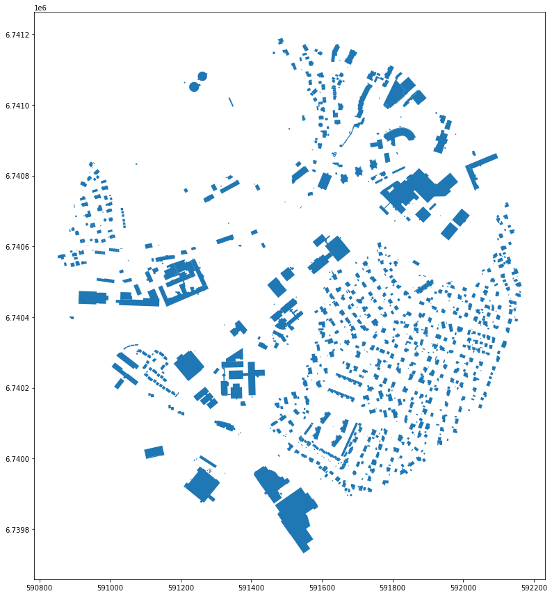

```python
# Plotte-kommandoen kan også gjøres direkte på GeoDataFrame
bygninger.plot(figsize=(15,15))
```

### Egenhofer-relasjoner krysstestet mellom alle geometrier i to GeoDataFrames

Vi ønsker å finne bygningene som ligger inne i teig-polygonene for Smaragd og Beryll.

I dokumentasjonen for contains leser vi: *This method works in a row-wise manner*

[figure not shown]

Vi må derfor tvinge GeoPandas til å gjøre contains-testen på alle de andre radene også, som vist nedenfor.

- apply-funksjonen kjører en funksjon på alle elementene i en GeoSeries eller GeoDataFrame, her: GeoSeries (bygninger.geometry)
- lambda er et Python-nøkkelord for å definere en anonym funksjon - det vil si en funksjon uten navn, definert her for å brukes bare her
- x representerer en enkelt-geometri, det vil si ett element fra geometry-kolonnen. Gjennom apply-funksjonaliteten vil x representere alle geometri-elementene, én etter én
- .any()-funksjonen returnerer True hvis noen av testene er sanne, her: at ett av teig-polygonene inneholder den aktuelle x'en, dvs. et bygningspolygon

```python
# oppdaterer bygninger med en ny kolonne, Beryll_Smaragd, med True/False, som angir om bygningene ligger innenfor noen av teig-polygonene
bygninger['Beryll_Smaragd'] = bygninger.geometry.apply(lambda x: teiger.geometry.contains(x).any())
```

```python
# betingelsen inne i parentesen angir hvilke rader som skal hentes ut.
bygninger_Beryll_Smaragd = bygninger[bygninger.Beryll_Smaragd == True]
bygninger_Beryll_Smaragd
```

|  | OBJECTID | objtype | bygningsnummer | datafangstdato | lokalid | navnerom | versjonid | produkt | versjon | undertype | ... | kopidato | bygningstype | bygningsstatus | kommunenummer | innmalingsstatus | medium | SHAPE_Length | SHAPE_Area | geometry | Beryll_Smaragd |
| --- | --- | --- | --- | --- | --- | --- | --- | --- | --- | --- | --- | --- | --- | --- | --- | --- | --- | --- | --- | --- | --- |
| 91 | 3140 | AnnenBygning | NaN | None | 569d3e31-732e-4573-989d-e8974d99aa3b | http://data.geonorge.no/SFKB/FKB-Bygning/so | 2019-12-17 10:52:45.063000 | None | None | None | ... | 2020-10-26T08:02:49 | NaN | None | None | None | None | 12.423114 | 9.16520 | MULTIPOLYGON Z (((591464.400 6740433.940 184.9... | True |
| 283 | 9906 | Bygning | 7482434.0 | 2007-04-30T00:00:00 | a1d5cdb0-2cab-4630-90f8-db5360a4e6bf | http://data.geonorge.no/SFKB/FKB-Bygning/so | 2019-12-17 10:52:45.063000 | None | None | None | ... | 2020-10-26T08:03:00 | 621.0 | TB | 3407 | None | None | 147.531351 | 894.65440 | MULTIPOLYGON Z (((591482.390 6740523.390 198.8... | True |
| 834 | 29039 | Bygning | 300671356.0 | None | a174bb93-fb90-4bd3-b4df-97f6528abe83 | http://data.geonorge.no/SFKB/FKB-Bygning/so | 2019-12-17 10:52:45.063000 | None | None | None | ... | 2020-10-26T08:03:51 | 621.0 | FA | 3407 | None | None | 163.858066 | 1581.58470 | MULTIPOLYGON Z (((591457.090 6740476.920 191.2... | True |
| 1048 | 34964 | Takoverbygg | NaN | None | 229bad4a-ad07-4ec4-a139-d85aaab70abf | http://data.geonorge.no/SFKB/FKB-Bygning/so | 2019-12-17 10:52:45.063000 | None | None | None | ... | 2020-10-26T08:08:36 | NaN | None | None | None | None | 19.758782 | 24.19165 | MULTIPOLYGON Z (((591516.280 6740536.880 190.1... | True |

4 rows × 26 columns

```python
bygninger_Beryll_Smaragd.plot(figsize=(6,10))
```

[output not shown]

### En enklere måte - bruk av Spatial Join- eller Overlay-funksjon

Egenhofer-relasjonene som er vist ovenfor tilhører GeoSeries-objektet og opererer radvis. Geopandas har også funksjoner som tilsvarer det vi finner i GIS-systemer som ArcGIS og QGIS og som automatisk krysstester alle geometrier.

Se [spatial join](https://geopandas.org/en/stable/docs/reference/api/geopandas.sjoin.html#geopandas.sjoin) og overlay. I dette tilfellet vil disse metoden gi samme resultat.

I dokumentasjonen for GeoPandas finner vi disse under [API/Tools](https://geopandas.org/en/stable/docs/reference/tools.html).

```python
bygninger_Beryll_Smaragd_sjoin = gpd.sjoin(bygninger, teiger)

bygninger_Beryll_Smaragd_sjoin.plot(figsize=(6,10))
```

[output not shown]

```python
bygninger_Beryll_Smaragd_overlay = gpd.overlay(bygninger, teiger)

bygninger_Beryll_Smaragd_overlay.plot(figsize=(6,10))
```

[output not shown]